# Reproducible Research: Assignment: Course Project 1

Abhay Prasad

February 20, 2016

## Loading necessary R packges and readying the R Studio environment

The code chunk below is to clear all pre-existing variables and to set or load packages that will be required. These packages have already been installed [using “intall.packages()”].

```r
rm(list=ls(all=TRUE)) # To remove all variables from the environment at the onset. Helps in faster processing.
ls()
```

```
## character(0)
```

```r
options(rpubs.upload.method = "internal")
echo = TRUE  # To make the code chunks visible in the Knitted output
options(scipen = 1)  # To turn off scientific notations for numbers
library(lattice)
library(R.utils) # Primarily needed to process the Bunzip2 raw data file
```

```r
library(ggplot2)
library(stringr)
library(plyr)
require(gridExtra)
setwd("~/RepResPA1Feb16") # Setting working directory for this assignment
```

## Loading and processing the data

The data for this assignment can be downloaded from the course web site URL: https://d396qusza40orc.cloudfront.net/repdata%2Fdata%2Factivity.zip

The raw data file was downloaded using the following code. This code is shown as text rather than as an executable code chunk to avoid the time-consuming steps of downloading and unzipping the file running repeatedly:

fileUrl <- “http://d396qusza40orc.cloudfront.net/repdata%2Fdata%2Factivity.zip”

download.file(fileUrl, destfile=“~/RepResPA1ActivityData.zip”)

unzip(“RepResPA1ActivityData.zip”)

### Data Loading

```r
rawdata <- read.csv("~/RepResPA1Feb16/activity.csv", colClasses = c("integer", "Date", "factor"))
dim(rawdata) #This should be 17568 rows and 3 columns
```

```
## [1] 17568     3
```

```r
rawdata$month <- as.numeric(format(rawdata$date, "%m"))
```

## What is mean total number of steps taken per day?

For this part of the assignment, you can ignore the missing values in the dataset.

```r
dataexNA <- na.omit(rawdata) #Omits rows with missing values in the dataset
rownames(dataexNA) <- 1:nrow(dataexNA)
head(dataexNA)
```

```
##   steps       date interval month
## 1     0 2012-10-02        0    10
## 2     0 2012-10-02        5    10
## 3     0 2012-10-02       10    10
## 4     0 2012-10-02       15    10
## 5     0 2012-10-02       20    10
## 6     0 2012-10-02       25    10
```

```r
dim(dataexNA)
```

```
## [1] 15264     4
```

### Histogram of the total number of steps taken each day

```
## stat_bin: binwidth defaulted to range/30. Use 'binwidth = x' to adjust this.
```

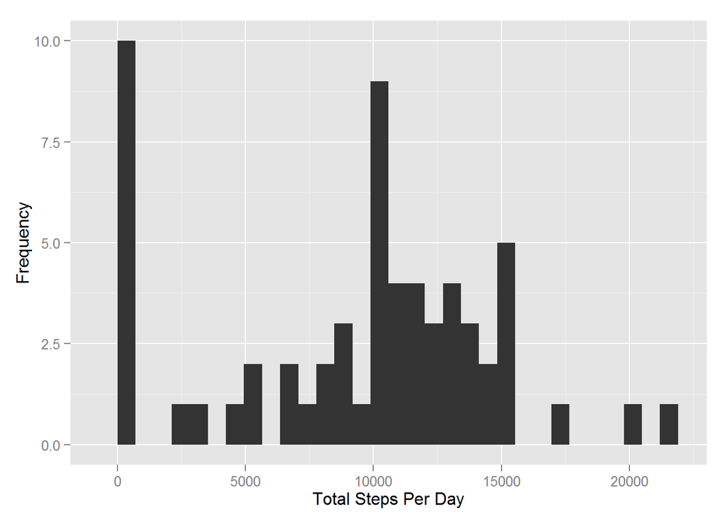

```r
numSteps <- tapply(rawdata$steps, rawdata$date, sum, na.rm=TRUE)
qplot(numSteps, xlab='Total Steps Per Day', ylab='Frequency')
```

### Mean and median number of steps taken each day

```r
totalSteps <- aggregate(dataexNA$steps, list(Date = dataexNA$date), FUN = "sum")$x
mean(totalSteps)
```

```
## [1] 10766.19
```

```r
median(totalSteps)
```

```
## [1] 10765
```

## What is the average daily activity pattern?

### Time series plot of the average number of steps taken

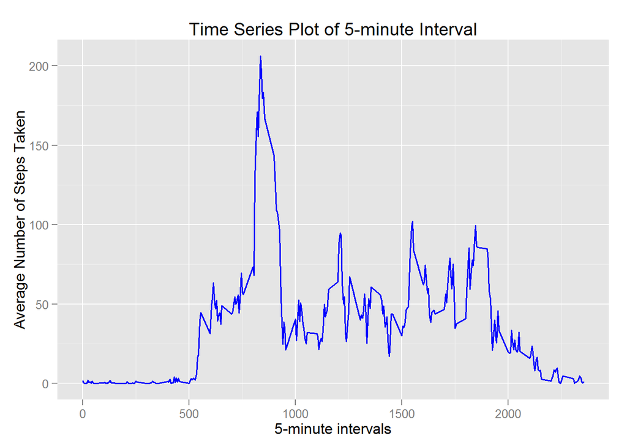

```r
avgSteps <- aggregate(dataexNA$steps, list(interval = as.numeric(as.character(dataexNA$interval))), FUN = "mean")
names(avgSteps)[2] <- "meanOfSteps"
ggplot(avgSteps, aes(interval, meanOfSteps)) + geom_line(color = "blue", size = 0.7) + labs(title = "Time Series Plot of 5-minute Interval", x = "5-minute intervals", y = "Average Number of Steps Taken")
```

The 5-minute interval that, on average, contains the maximum number of steps

```r
avgSteps[avgSteps$meanOfSteps == max(avgSteps$meanOfSteps), ]
```

```
##     interval meanOfSteps
## 104      835    206.1698
```

### Calculate and report the total number of missing values in the dataset (i.e. the total number of rows with NAs)

```r
sum(is.na(rawdata)) # To calculate and report the total number of missing values in the original dataset (i.e. the total number of rows with NAs)
```

```
## [1] 2304
```

```r
dim(rawdata) - dim(dataexNA)  # Another way to verify the  calculated total number of missing values in the original dataset
```

```
## [1] 2304    0
```

### Devise a strategy for filling in all of the missing values in the dataset and Create a new dataset that is equal to the original dataset but with the missing data filled in.

```r
newData <- rawdata
for (i in 1:nrow(newData)) {
    if (is.na(newData$steps[i])) {
        newData$steps[i] <- avgSteps[which(newData$interval[i] == avgSteps$interval), ]$meanOfSteps
    }
}
head(newData)
```

```
##       steps       date interval month
## 1 1.7169811 2012-10-01        0    10
## 2 0.3396226 2012-10-01        5    10
## 3 0.1320755 2012-10-01       10    10
## 4 0.1509434 2012-10-01       15    10
## 5 0.0754717 2012-10-01       20    10
## 6 2.0943396 2012-10-01       25    10
```

```r
dim(newData)
```

```
## [1] 17568     4
```

```r
sum(is.na(newData))
```

```
## [1] 0
```

```r
dim(rawdata) - dim(newData)
```

```
## [1] 0 0
```